# Stackoverflow 2018 survey Exploratory Data Analysis

Loading all the required package for this Analysis

```r
library(readxl)
library(tidyverse)
library(ggplot2)
library(highcharter)
library(plotly)
library(stringr)
library(viridis)
library(gridExtra)
library(tidyverse)
library(highcharter)
library(plotly)
library(dygraphs)
library(lubridate)
library("viridisLite")
library(leaflet)
library(countrycode)
library(xts)
library(htmltools)
library(spatial)
library(rlang)
library(ggplot2)
library(purrr)
library(rworldmap)
library (igraph)
library(randomcoloR)

if (!require("pacman")) install.packages("pacman")
pacman::p_load(tidyverse, skimr, GGally, plotly, viridis, caret, randomForest, e1071, rpart,
               xgboost, h2o, corrplot, rpart.plot, corrgram, lightgbm, ggplot2, highcharter,
               ggthemes, psych, scales, treemap, treemapify, repr, cowplot, magrittr, ggpubr,
               RColorBrewer, plotrix, ggrepel,dplyr,tidyr,countrycode,gdata,visNetwork,stringr,scales,reshape2)


options(repr.plot.width=8, repr.plot.height=6)
options(warn=-1)
```

**Introduction:** This 2018 Developer Stackoverflow Survey results are organized as:

**survey_results_public** contains the main survey results, one respondent per row and one column per question

This dataset consists the responses of 98,855 respondents with 129 feature variables.

**Focused area:**

- **WHO’s PART OF THE SURVEY?**
- **GENDER CLASSIFICATION BASED ON AGE**
- **EMPLOYMENT STATUS OF DEVELOPERS**
- **FEELING LEFT OUT**
- **AI**
- **PYTHON vs R**

```r
survey18 <- read.csv("/Users/raj/Downloads/developer_survey_2018 (1)/survey_results_public.csv")
head(survey18)
```

|  | Respondent | Hobby | OpenSource | Country | Student | Employment | FormalEducation | UndergradMajor | CompanySize | DevType | YearsCoding | YearsCodingProf | JobSatisfaction | CareerSatisfaction | HopeFiveYears | JobSearchStatus | LastNewJob | AssessJob1 | AssessJob2 | AssessJob3 | AssessJob4 | AssessJob5 | AssessJob6 | AssessJob7 | AssessJob8 | AssessJob9 | AssessJob10 | AssessBenefits1 | AssessBenefits2 | … |
| --- | --- | --- | --- | --- | --- | --- | --- | --- | --- | --- | --- | --- | --- | --- | --- | --- | --- | --- | --- | --- | --- | --- | --- | --- | --- | --- | --- | --- | --- | --- |
| 1 | 1 | Yes | No | Kenya | No | Employed part-time | Bachelor’s degree (BA, BS, B.Eng., etc.) | Mathematics or statistics | 20 to 99 employees | Full-stack developer | 3-5 years | 3-5 years | Extremely satisfied | Extremely satisfied | Working as a founder or co-founder of my own company | I’m not actively looking, but I am open to new opportunities | Less than a year ago | 10 | 7 | 8 | 1 | 2 | 5 | 3 | 4 | 9 | 6 | NA | NA | … |
| 2 | 3 | Yes | Yes | United Kingdom | No | Employed full-time | Bachelor’s degree (BA, BS, B.Eng., etc.) | A natural science (ex. biology, chemistry, physics) | 10,000 or more employees | Database administrator;DevOps specialist;Full-stack developer;System administrator | 30 or more years | 18-20 years | Moderately dissatisfied | Neither satisfied nor dissatisfied | Working in a different or more specialized technical role than the one I'm in now | I am actively looking for a job | More than 4 years ago | 1 | 7 | 10 | 8 | 2 | 5 | 4 | 3 | 6 | 9 | 1 | 5 | … |
| 3 | 4 | Yes | Yes | United States | No | Employed full-time | Associate degree | Computer science, computer engineering, or software engineering | 20 to 99 employees | Engineering manager;Full-stack developer | 24-26 years | 6-8 years | Moderately satisfied | Moderately satisfied | Working as a founder or co-founder of my own company | I’m not actively looking, but I am open to new opportunities | Less than a year ago | NA | NA | NA | NA | NA | NA | NA | NA | NA | NA | NA | NA | … |
| 4 | 5 | No | No | United States | No | Employed full-time | Bachelor’s degree (BA, BS, B.Eng., etc.) | Computer science, computer engineering, or software engineering | 100 to 499 employees | Full-stack developer | 18-20 years | 12-14 years | Neither satisfied nor dissatisfied | Slightly dissatisfied | Working as a founder or co-founder of my own company | I’m not actively looking, but I am open to new opportunities | Less than a year ago | NA | NA | NA | NA | NA | NA | NA | NA | NA | NA | NA | NA | … |
| 5 | 7 | Yes | No | South Africa | Yes, part-time | Employed full-time | Some college/university study without earning a degree | Computer science, computer engineering, or software engineering | 10,000 or more employees | Data or business analyst;Desktop or enterprise applications developer;Game or graphics developer;QA or test developer;Student | 6-8 years | 0-2 years | Slightly satisfied | Moderately satisfied | Working in a different or more specialized technical role than the one I'm in now | I’m not actively looking, but I am open to new opportunities | Between 1 and 2 years ago | 8 | 5 | 7 | 1 | 2 | 6 | 4 | 3 | 10 | 9 | 1 | 10 | … |
| 6 | 8 | Yes | No | United Kingdom | No | Employed full-time | Bachelor’s degree (BA, BS, B.Eng., etc.) | Computer science, computer engineering, or software engineering | 10 to 19 employees | Back-end developer;Database administrator;Front-end developer;Full-stack developer | 6-8 years | 3-5 years | Moderately satisfied | Slightly satisfied | Working in a different or more specialized technical role than the one I'm in now | I am actively looking for a job | Between 2 and 4 years ago | 8 | 5 | 4 | 9 | 1 | 3 | 6 | 2 | 10 | 7 | 1 | 3 | … |

**WHO’s PART OF THE SURVEY?** MOST REPRESENTED COUNTRIES

```r
## top countries with respect to SO
survey18 %>%
  filter(!is.na(Country)) %>%
  group_by(Country) %>%
  count() %>%
  arrange(desc(n)) %>%
  #head(10) %>%
  hchart('treemap',hcaes(x = Country, value = n, color = n)) %>%
  hc_title(text = 'Countries from where overall respondents come from')
```

[interactive chart not shown]

**Summary:**

Out of 98,855 developers, following countries have highest number of respondents :

• United States : 20,309 Developers

• India : 13,721 Developers

• Germany : 6,459 Developers

• United Kingdom : 6,221 Developers

• Canada : 3,393 Developers

**GENDER CLASSIFICATION BASED ON AGE**

```r
##Bifurcation by age and gender
survey18 %>%
  filter(!is.na(Gender)) %>%
  filter(!is.na(Age)) %>%
  filter(Gender %in% c('Male','Female')) %>%
  select(Gender,  Age) %>%
  mutate(Gender = str_split(Gender, pattern = ";")) %>%
  unnest(Gender) %>%
  group_by(Gender, Age) %>%
  summarise(Count = n()) %>%
  arrange(desc(Count)) %>%
  ungroup() %>%
  mutate(Gender = reorder(Gender,Count)) %>%
  hchart('column',hcaes('Gender','Count', group = 'Age')) %>%
  #hc_colors(c("darkorange", "darkgray")) %>%
  hc_title(text = 'Male vs Female by Age - Stack Overflow Members') %>%
  hc_yAxis(type = 'logarithmic')
```

[interactive chart not shown]

The above interactive dashboard depicts the proportion of users in the Stack Overflow community bifurcated within varying degrees based on age classification.

**INSIGHTS**

• Users under the age of 18 strongly support a special area for beginners.

• Users between 18-34 years old strongly support adding a career growth Q & A to Stack Overflow.

• Women show stronger support for all of the hypothetical tools as compared to men, and women show the strongest support for a career growth Q & A and employer/job reviews

• Salary by Gender: Males tend to have a slighter median salary. Also, male respondents tend to have a higher presence compared to female respondents.

**EMPLOYMENT STATUS OF DEVELOPERS**

```r
##chalktheme
survey18 %>%
  filter(!is.na(Employment)) %>%
  count(Employment) %>%
  hchart('column',hcaes('Employment','n')) %>%
  hc_title(text = "Employment Type") %>%
  hc_subtitle(text = "Source: Stack Overflow Dev Survey") %>%  hc_add_theme(hc_theme_chalk())
```

[interactive chart not shown]

• Employeed full-time : 74 %

• Independent Contractor, Freelancer or Self-employed : 9.74 %

• Not employed but looking for work : 6.09 %

• Employed part-time : 5.64 %

• Not employeed and not looking for work : 4.33 %

• Retired : 0.238 %

**FEELING LEFT OUT**

```r
survey18 %>%
  filter(!is.na(Country),
         !is.na(StackOverflowConsiderMember),
         StackOverflowConsiderMember %in% c("Yes","No" )) %>%
  group_by(Country) %>%
  mutate(n = n())  %>%
  filter(n > 150) %>%
  ungroup() %>%
  select(Country,StackOverflowConsiderMember) %>%
  group_by(Country,StackOverflowConsiderMember) %>%
  count()  %>%
  #filter(n > 150) %>%
  spread(StackOverflowConsiderMember,n) %>%
  mutate(No_to_Yes = round((No/Yes) * 100)) %>%
  arrange(desc(No_to_Yes)) -> no_to_yes

View(head(no_to_yes,10))
  data(worldgeojson, package = "highcharter")


highchart() %>%
  hc_add_series_map(worldgeojson, no_to_yes, value = "No_to_Yes", joinBy = c('name','Country'))  %>%
  #hc_colors(c("darkorange", "darkgray")) %>%
  hc_colorAxis(stops = color_stops()) %>%
  hc_title(text = "Countries - Ratio of No to Yes (feeling part of SO)") %>%
  hc_subtitle(text = "Less is Better")
```

[interactive chart not shown]

**Countries**

The idea here is to have a normalized index that could represent the crowd based on Country they belong to, feeling left out (not considering to be part of Stack Overflow Member). With taking entries from the countries that had minimum 150 respondents, Top 5 countries containing respondents feeling left out are:

• Finland

• Norway

• New Zealeand

• Canada

• United Kingdom

**AI**

Whose Responsibility?

```r
## AI RESPONSIBLE
survey18 %>%
  filter(!is.na(AIResponsible)) %>%
  count(AIResponsible) %>%
  hchart("pie",hcaes(x = "AIResponsible", y = "n")) %>%
  hc_add_theme(hc_theme_darkunica()) %>%
  hc_title(text = 'What developers think whose responsibility to consider the ramifications of increasingly advanced AI technology?')
```

[interactive chart not shown]

Close to half of the respondents feel, Developers and organizations who create AI products and solutions must take the ownership of responsibility in building ethical AI, while more than a quarter supports a body or Government to do the same.

**PYTHON vs R**

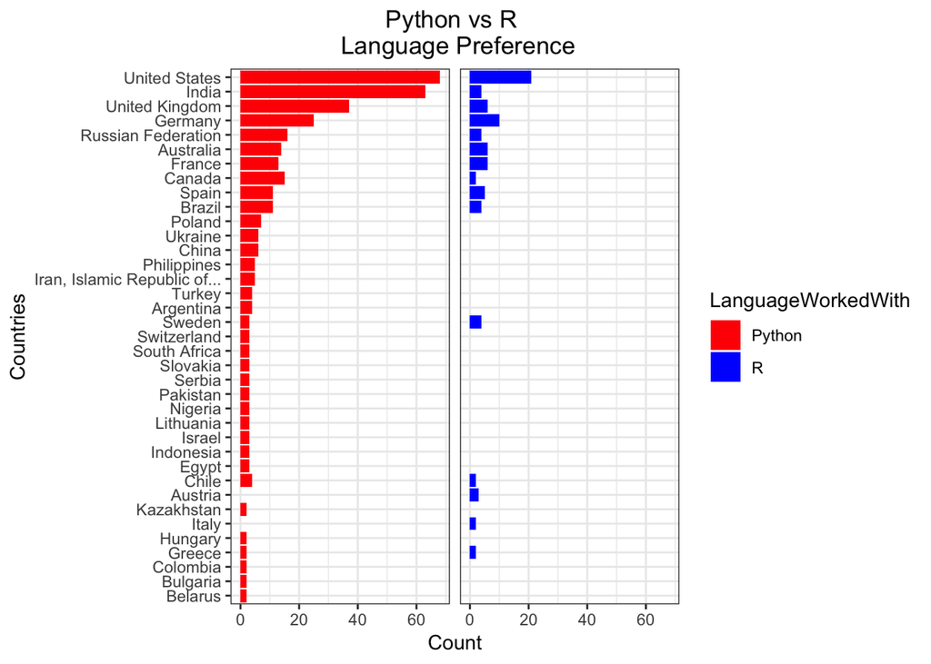

```r
##Python vs R
options(repr.plot.width=10, repr.plot.height=8)

languages.preference <- survey18 %>%
  filter(LanguageWorkedWith == "Python"| LanguageWorkedWith == "R") %>%
  filter(!is.na(Country)) %>% group_by(Country, LanguageWorkedWith) %>% summarise(Count=n()) %>%
  arrange(desc(Count)) %>% head(50) %>%
  ggplot(aes(x=reorder(Country, Count), y=Count, fill=LanguageWorkedWith)) +
  geom_bar(stat="identity") + facet_wrap(~LanguageWorkedWith) + coord_flip() + theme_bw() +
  theme(plot.title=element_text(hjust=0.5), strip.background = element_blank(), strip.text.x = element_blank()) +
  labs(x="Countries", y="Count", title="Python vs R \n Language Preference") +
  scale_fill_manual(values=c("red", "blue"))

languages.preference
```

**Summary:**

• Top 5 Countries Respondents: The top 5 countries with most respondents use more Python than R.

• R Language: Proportion wise the US and Germany use R more considerably than other countries.

• Python Language: India, US and the UK use Python considerably more than other Countries.

• Employment Status: Most respondents are employed full-time (Almost 75% of respondents).

• Hobby and Student: Most people that are not a student tend to Code as a Hobby.

• Salary Distribution: Normal distribution of salary is right-skewed and logarithmic distribution is left-skewed.

• Salary by Country: The US, Switzerland and Israel tend to offer the best salary.

• Employment: Switzerland and South Africa are amongst the highest in employment.